# final_project_654

Errol Kaylor

2022-12-09

Goal is to predict player ratings based on turns data!

Link to data: https://www.kaggle.com/competitions/scrabble-player-rating/data

Link to github repo: https://github.com/errolkaylor/654_edld_fp_scrabble

## Project Intro

Our goal here is to understand how well we can predict player scrabble ratings based on online gameplay against computer opponents! Scrabble ratings are measures of relative scrabble skill of players, with a median score of tournament player being roughly 1200. Predicting player ratings is an important scrabble tournament problem, as creating fair divisons for competition is of the utmost importance. These models may also lead to simpler ELO calculations for players, as it is a relatively involved statistic to calculate for each player.

```r
games <- import(here("data/games.csv/games.csv")) %>%
    as_tibble()
test <- import(here("data/test.csv/test.csv")) %>%
    as_tibble()
train <- import(here("data/train.csv/train.csv")) %>%
    as_tibble()
turns <- import(here("data/turns.csv/turns.csv")) %>%
    as_tibble()
#add player names to games data

games_train_full <- games %>%
    left_join(train) %>%
    filter(!(first==nickname)) %>%
    mutate(second_player=nickname) %>%
    separate(col=created_at,sep = " ",into = c("date","time")) %>%
    separate(col=date,sep="-",into = c("year","month","day")) %>%
    separate(col=time,sep=":",into = c("hour","minute","second")) %>%
    mutate_at(c(6:11),as.numeric)
games_train_fuller <- games_train_full %>%
    mutate(game_winner = if_else(winner==1,second_player,first),
           winner_type = if_else(game_winner %in% c("BetterBot","STEEBot","HastyBot"),"Bot","Human")) %>%
    select(-c(14,16,18)) %>%
    relocate(rating,.after = winner_type) %>%
    mutate(game_end_reason = as_factor(game_end_reason))

games_test_full <- games %>%
    left_join(test) %>%
    filter(!(first==nickname)) %>%
    mutate(second_player=nickname) %>%
    separate(col=created_at,sep = " ",into = c("date","time")) %>%
    separate(col=date,sep="-",into = c("year","month","day")) %>%
    separate(col=time,sep=":",into = c("hour","minute","second")) %>%
    mutate_at(c(6:11),as.numeric)
games_test_fuller <- games_test_full %>%
    mutate(game_winner = if_else(winner==1,second_player,first),
           winner_type = if_else(game_winner %in% c("BetterBot","STEEBot","HastyBot"),"Bot","Human")) %>%
    select(-c(14,16,18)) %>%
    relocate(rating,.after = winner_type) %>%
    mutate(game_end_reason = as_factor(game_end_reason)) %>%
    filter(!is.na(rating))

outcome <- c('rating')

id      <- c('game_id')

categorical <- c('time_control_name','game_end_reason','lexicon','rating_mode','winner_type')

numeric <- c('game_duration_seconds','score')

cyclic <- c('day','month','hour','minute','second')


blueprint_games <- recipe(x=games_train_fuller,
                          vars=c(id,outcome,categorical,numeric,cyclic),
                          roles=c('id','outcome',rep('predictor',12))) %>%
    step_harmonic('month',frequency = 1,cycle_size=3,role='predictor') %>%
    step_harmonic('day',frequency = 1,cycle_size=31,role='predictor') %>%
    step_harmonic('hour',frequency = 1,cycle_size=12,role='predictor') %>%
    step_harmonic('minute',frequency = 1,cycle_size=60,role='predictor') %>%
    step_harmonic('second',frequency = 1,cycle_size=60,role='predictor') %>%
    step_dummy('lexicon',one_hot = TRUE) %>%
    step_dummy('time_control_name',one_hot=TRUE) %>%
    step_dummy('winner_type',one_hot=TRUE) %>%
    step_dummy('rating_mode',one_hot=TRUE) %>%
    step_dummy('game_end_reason',one_hot=TRUE) %>%
    step_normalize('game_duration_seconds') %>%
    step_normalize('score') %>%
    step_normalize(c('month_sin_1','day_sin_1','hour_sin_1','minute_sin_1','second_sin_1','month_cos_1','day_cos_1','hour_cos_1','minute_cos_1','second_cos_1'))
```

Our dataset consists of game, player rating, and turn data for ~73,000 scrabble games played against bots on woogles.io. For game, we are given a game id, player names, which player won and went first, game creation time and date, and the dictionary (“Lexicon”) being used in the particular game. Additionally, we are given test and training datasets with game ids, player scores, and player ratings before the game is played. Finally, we have turn data for each scrabble game played, that includes infomration on current player score, player move type, player points scored (if points were scored with the move), where the player put their tiles, and what tiles they have in their rack. I used player rack to calculate a new metric, rack score. This metric is the total point value of tiles in the players rack before each move, and is used in comparison to points scored each turn to provide more evidence for scrabble skill.

```r
games_train_fuller = games_train_fuller[sample(nrow(games_train_fuller)),]

folds1 = cut(seq(1,nrow(games_train_fuller)),breaks=10,labels=FALSE)

# Create the list for each fold

my.indices1 <- vector('list',10)

for(i in 1:10){
    my.indices1[[i]] <- which(folds1!=i)
}
cv <- trainControl(method          = "cv",
                   index           = my.indices1)


ff_glimpse(games_train_fuller)
```

```
## $Continuous
##                                       label var_type     n missing_n
## game_id                             game_id    <int> 50410         0
## winner                               winner    <int> 50410         0
## year                                   year    <dbl> 50410         0
## month                                 month    <dbl> 50410         0
## day                                     day    <dbl> 50410         0
## hour                                   hour    <dbl> 50410         0
## minute                               minute    <dbl> 50410         0
## second                               second    <dbl> 50410         0
## initial_time_seconds   initial_time_seconds    <int> 50410         0
## game_duration_seconds game_duration_seconds    <dbl> 50410         0
## score                                 score    <int> 50410         0
## rating                               rating    <int> 50410         0
##                       missing_percent    mean      sd    min quartile_25
## game_id                           0.0 36367.3 21020.4    1.0     18139.8
## winner                            0.0     0.4     0.5   -1.0         0.0
## year                              0.0  2022.0     0.0 2022.0      2022.0
## month                             0.0     8.5     0.6    7.0         8.0
## day                               0.0    15.3     9.0    1.0         7.0
## hour                              0.0    11.3     6.9    0.0         5.0
## minute                            0.0    29.5    17.2    0.0        15.0
## second                            0.0    29.5    17.3    0.0        14.0
## initial_time_seconds              0.0  1216.8   713.0   15.0       900.0
## game_duration_seconds             0.0   492.5   330.6   19.8       260.8
## score                             0.0   392.6    74.8  -64.0       345.0
## rating                            0.0  1876.5   232.5 1033.0      1664.0
##                        median quartile_75     max
## game_id               36339.5     54624.8 72773.0
## winner                    0.0         1.0     1.0
## year                   2022.0      2022.0  2022.0
## month                     9.0         9.0     9.0
## day                      15.0        22.0    31.0
## hour                     12.0        17.0    23.0
## minute                   29.0        44.0    59.0
## second                   29.0        44.0    59.0
## initial_time_seconds   1200.0      1200.0  3600.0
## game_duration_seconds   411.5       638.5  4444.8
## score                   391.5       439.0   939.0
## rating                 1909.0      2062.0  2510.0
```

[output cut: 14 more lines]

```
## game_end_reason          4 "STANDARD", "RESIGNED", "TIME", "CONSECUTIVE_ZEROES"
## lexicon                  4                                                    -
## rating_mode              2                                                    -
## second_player          931                                                    -
## game_winner            896                                                    -
## winner_type              2                                                    -
##                             levels_count             levels_percent
## first                                  -                          -
## time_control_name                      -                          -
## game_end_reason   47694, 1284, 1249, 183 94.61,  2.55,  2.48,  0.36
## lexicon                                -                          -
## rating_mode                            -                          -
## second_player                          -                          -
## game_winner                            -                          -
## winner_type                            -                          -
```

```r
mod_1 <- caret::train(blueprint_games,
                      data=games_train_fuller,
                      method='glmnet',
                      tuneGrid = expand.grid( alpha = seq(0.0001,1,length = 20),
                                              lambda = seq(0.0001,1,length = 20)),
                      trControl = cv)
mod_1
```

```
## glmnet
##
## 50410 samples
##    19 predictor
##
## Recipe steps: harmonic, harmonic, harmonic, harmonic, harmonic, dummy,
##  dummy, dummy, dummy, dummy, normalize, normalize, normalize
## Resampling: Cross-Validated (10 fold)
## Summary of sample sizes: 45369, 45369, 45369, 45369, 45369, 45369, ...
## Resampling results across tuning parameters:
##
##   alpha       lambda      RMSE      Rsquared   MAE
##   0.00010000  0.00010000  143.7769  0.6185196  110.4038
##   0.00010000  0.05272632  143.7769  0.6185196  110.4038
##   0.00010000  0.10535263  143.7769  0.6185196  110.4038
##   0.00010000  0.15797895  143.7769  0.6185196  110.4038
##   0.00010000  0.21060526  143.7769  0.6185196  110.4038
##   0.00010000  0.26323158  143.7769  0.6185196  110.4038
##   0.00010000  0.31585789  143.7769  0.6185196  110.4038
##   0.00010000  0.36848421  143.7769  0.6185196  110.4038
##   0.00010000  0.42111053  143.7769  0.6185196  110.4038
##   0.00010000  0.47373684  143.7769  0.6185196  110.4038
##   0.00010000  0.52636316  143.7769  0.6185196  110.4038
##   0.00010000  0.57898947  143.7769  0.6185196  110.4038
##   0.00010000  0.63161579  143.7769  0.6185196  110.4038
##   0.00010000  0.68424211  143.7769  0.6185196  110.4038
##   0.00010000  0.73686842  143.7769  0.6185196  110.4038
##   0.00010000  0.78949474  143.7769  0.6185196  110.4038
##   0.00010000  0.84212105  143.7769  0.6185196  110.4038
##   0.00010000  0.89474737  143.7769  0.6185196  110.4038
##   0.00010000  0.94737368  143.7769  0.6185196  110.4038
##   0.00010000  1.00000000  143.7769  0.6185196  110.4038
##   0.05272632  0.00010000  143.4884  0.6192140  109.9343
##   0.05272632  0.05272632  143.4884  0.6192140  109.9343
##   0.05272632  0.10535263  143.4884  0.6192140  109.9343
##   0.05272632  0.15797895  143.4884  0.6192140  109.9343
##   0.05272632  0.21060526  143.4884  0.6192140  109.9343
##   0.05272632  0.26323158  143.4884  0.6192140  109.9343
##   0.05272632  0.31585789  143.4884  0.6192140  109.9343
##   0.05272632  0.36848421  143.4884  0.6192140  109.9343
```

[output cut: 361 more lines]

```
##   1.00000000  0.47373684  143.5033  0.6191417  109.9517
##   1.00000000  0.52636316  143.5080  0.6191212  109.9593
##   1.00000000  0.57898947  143.5133  0.6190973  109.9672
##   1.00000000  0.63161579  143.5190  0.6190718  109.9754
##   1.00000000  0.68424211  143.5249  0.6190452  109.9840
##   1.00000000  0.73686842  143.5317  0.6190148  109.9930
##   1.00000000  0.78949474  143.5390  0.6189819  110.0024
##   1.00000000  0.84212105  143.5468  0.6189466  110.0125
##   1.00000000  0.89474737  143.5551  0.6189089  110.0230
##   1.00000000  0.94737368  143.5639  0.6188689  110.0341
##   1.00000000  1.00000000  143.5731  0.6188269  110.0455
##
## RMSE was used to select the optimal model using the smallest value.
## The final values used for the model were alpha = 0.4737368 and lambda
##  = 0.3684842.
```

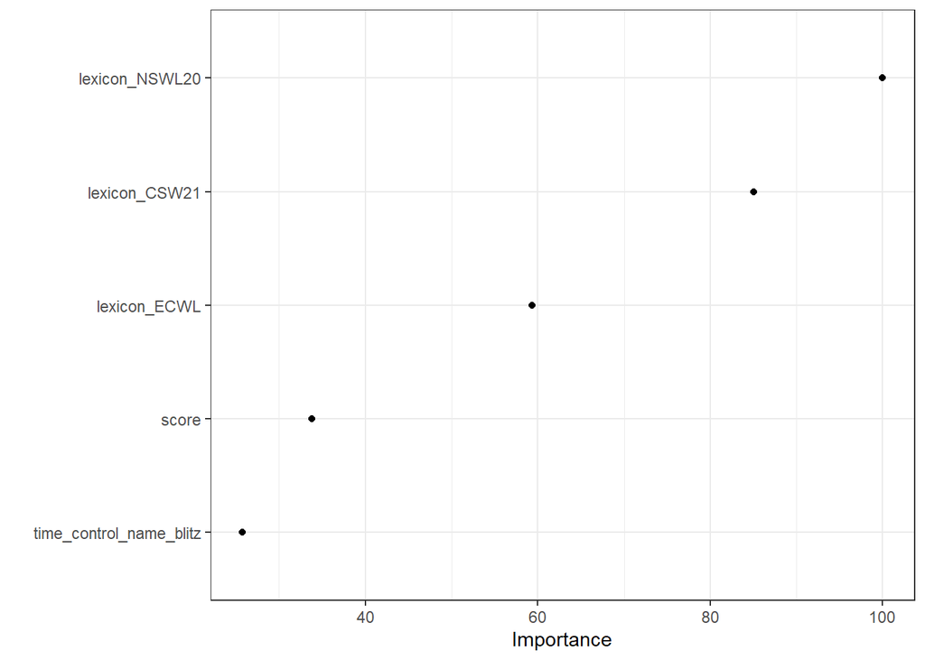

```r
vip(mod_1,num_features = 5, geom = "point") +
    theme_bw()
```

```r
rack_val <- function(rack_string){
                one <- str_count(rack_string,"[AEIOULNSTR]")
                two <- str_count(rack_string,"[DG]")*2
                three <- str_count(rack_string,"[BCMP]")*3
                four <-  str_count(rack_string,"[FHVWY]")*4
                five <-  str_count(rack_string,"[K]")*5
                six <-  str_count(rack_string,"[JX]")*8
                seven <- str_count(rack_string,"[QZ]")*10
                sum <- one + two + three + four + five + six + seven
}

turns <- turns %>%
    mutate(rack_values = rack_val(rack),
           proportion_points_scored = points/rack_values)

turns_summary <- turns %>%
    group_by(game_id) %>%
    summarize(avg_prop_points_scored = mean(proportion_points_scored,na.rm=TRUE),
              avg_points_scored = mean(points,na.rm=TRUE))

games_turns_combo <- games_train_fuller %>%
    left_join(turns_summary) %>%
    relocate(rating,.after = avg_points_scored) %>%
    filter(is.finite(avg_prop_points_scored ))
games_test_turns_combo <- games_test_fuller %>%
    left_join(turns_summary) %>%
    relocate(rating,.after = avg_points_scored) %>%
    filter(is.finite(avg_prop_points_scored ))
numeric_updated <- c('game_duration_seconds','score','avg_prop_points_scored','avg_points_scored')


blueprint_games_turns_combo <- recipe(x=games_turns_combo,
                          vars=c(id,outcome,categorical,numeric_updated,cyclic),
                          roles=c('id','outcome',rep('predictor',14))) %>%
    step_harmonic('month',frequency = 1,cycle_size=3,role='predictor') %>%
    step_harmonic('day',frequency = 1,cycle_size=31,role='predictor') %>%
    step_harmonic('hour',frequency = 1,cycle_size=12,role='predictor') %>%
    step_harmonic('minute',frequency = 1,cycle_size=60,role='predictor') %>%
    step_harmonic('second',frequency = 1,cycle_size=60,role='predictor') %>%
    step_dummy('lexicon',one_hot = TRUE) %>%
    step_dummy('time_control_name',one_hot=TRUE) %>%
    step_dummy('winner_type',one_hot=TRUE) %>%
    step_dummy('rating_mode',one_hot=TRUE) %>%
    step_dummy('game_end_reason',one_hot=TRUE) %>%
    step_normalize('game_duration_seconds') %>%
    step_normalize('score') %>%
    step_normalize('avg_points_scored') %>%
    step_normalize('avg_prop_points_scored') %>%
    step_normalize(c('month_sin_1','day_sin_1','hour_sin_1','minute_sin_1','second_sin_1','month_cos_1','day_cos_1','hour_cos_1','minute_cos_1','second_cos_1'))

games_turns_combo = games_turns_combo[sample(nrow(games_turns_combo)),]

folds2 = cut(seq(1,nrow(games_turns_combo)),breaks=10,labels=FALSE)

# Create the list for each fold

my.indices2 <- vector('list',10)

for(i in 1:10){
    my.indices2[[i]] <- which(folds2!=i)
}
cv <- trainControl(method          = "cv",
                   index           = my.indices2)


mod_2 <- caret::train(blueprint_games_turns_combo,
                      data=games_turns_combo,
                      method='glmnet',
                      tuneGrid = expand.grid( alpha = seq(0.0001,1,length = 20),
                                              lambda = seq(0.0001,1,length = 20)),
                      trControl = cv)

mod_2
```

```
## glmnet
##
## 50299 samples
##    21 predictor
##
## Recipe steps: harmonic, harmonic, harmonic, harmonic, harmonic, dummy,
##  dummy, dummy, dummy, dummy, normalize, normalize, normalize,
##  normalize, normalize
## Resampling: Cross-Validated (10 fold)
## Summary of sample sizes: 45269, 45269, 45269, 45269, 45269, 45270, ...
## Resampling results across tuning parameters:
##
##   alpha       lambda      RMSE      Rsquared   MAE
##   0.00010000  0.00010000  141.8178  0.6285880  108.2476
##   0.00010000  0.05272632  141.8178  0.6285880  108.2476
##   0.00010000  0.10535263  141.8178  0.6285880  108.2476
##   0.00010000  0.15797895  141.8178  0.6285880  108.2476
##   0.00010000  0.21060526  141.8178  0.6285880  108.2476
##   0.00010000  0.26323158  141.8178  0.6285880  108.2476
##   0.00010000  0.31585789  141.8178  0.6285880  108.2476
##   0.00010000  0.36848421  141.8178  0.6285880  108.2476
##   0.00010000  0.42111053  141.8178  0.6285880  108.2476
##   0.00010000  0.47373684  141.8178  0.6285880  108.2476
##   0.00010000  0.52636316  141.8178  0.6285880  108.2476
##   0.00010000  0.57898947  141.8178  0.6285880  108.2476
##   0.00010000  0.63161579  141.8178  0.6285880  108.2476
##   0.00010000  0.68424211  141.8178  0.6285880  108.2476
##   0.00010000  0.73686842  141.8178  0.6285880  108.2476
##   0.00010000  0.78949474  141.8178  0.6285880  108.2476
##   0.00010000  0.84212105  141.8178  0.6285880  108.2476
##   0.00010000  0.89474737  141.8178  0.6285880  108.2476
##   0.00010000  0.94737368  141.8178  0.6285880  108.2476
##   0.00010000  1.00000000  141.8178  0.6285880  108.2476
##   0.05272632  0.00010000  141.5821  0.6292697  107.8382
##   0.05272632  0.05272632  141.5821  0.6292697  107.8382
##   0.05272632  0.10535263  141.5821  0.6292697  107.8382
##   0.05272632  0.15797895  141.5821  0.6292697  107.8382
##   0.05272632  0.21060526  141.5821  0.6292697  107.8382
##   0.05272632  0.26323158  141.5821  0.6292697  107.8382
##   0.05272632  0.31585789  141.5821  0.6292697  107.8382
```

[output cut: 361 more lines]

```
##   1.00000000  0.42111053  141.5892  0.6292341  107.8344
##   1.00000000  0.47373684  141.5925  0.6292202  107.8394
##   1.00000000  0.52636316  141.5961  0.6292046  107.8448
##   1.00000000  0.57898947  141.6002  0.6291871  107.8507
##   1.00000000  0.63161579  141.6047  0.6291680  107.8569
##   1.00000000  0.68424211  141.6095  0.6291469  107.8634
##   1.00000000  0.73686842  141.6149  0.6291239  107.8705
##   1.00000000  0.78949474  141.6206  0.6290993  107.8783
##   1.00000000  0.84212105  141.6269  0.6290722  107.8861
##   1.00000000  0.89474737  141.6335  0.6290431  107.8941
##   1.00000000  0.94737368  141.6407  0.6290118  107.9026
##   1.00000000  1.00000000  141.6483  0.6289784  107.9115
##
## RMSE was used to select the optimal model using the smallest value.
## The final values used for the model were alpha = 1 and lambda = 0.2106053.
```

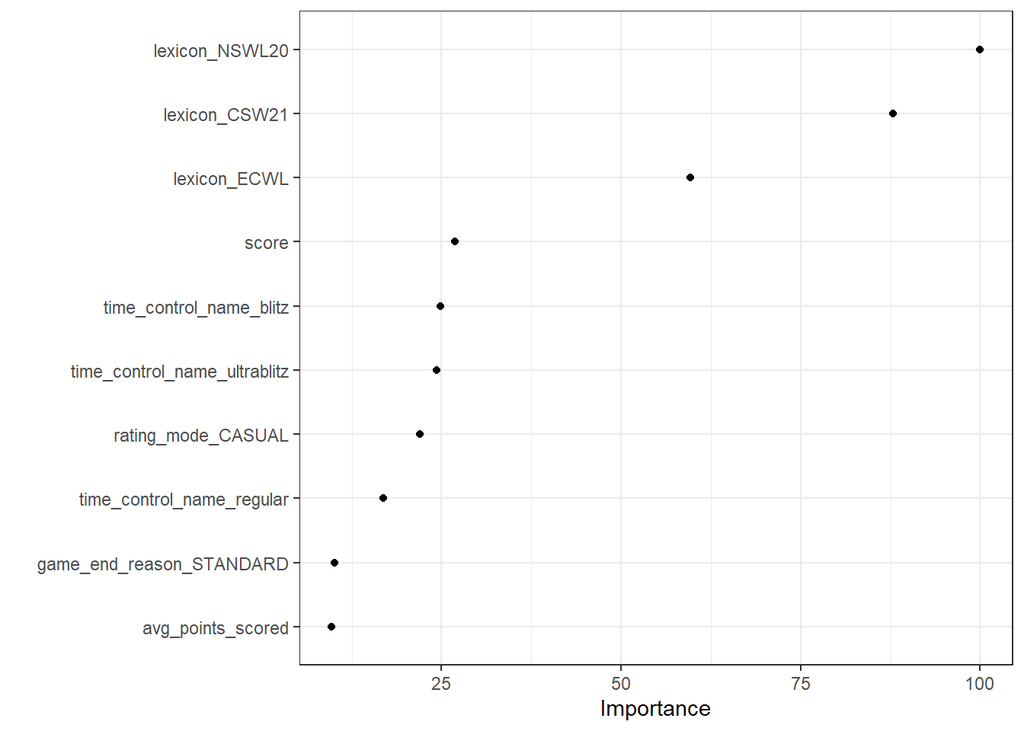

```r
vip(mod_2,num_features = 10, geom = "point") +
    theme_bw()
```

```r
rangergrid <- expand.grid(
    .mtry=10,
    .splitrule='variance',
    .min.node.size=2)

nbags <- c(seq(5,200,15))

bags<- vector('list',length(nbags))

for(i in 1:length(nbags)){
    bags[[i]] <- caret::train(blueprint_games_turns_combo,
                              data = games_turns_combo,
                              method = 'ranger',
                              tuneGrid = rangergrid,
                              trControl = cv,
                              num.trees = nbags[i],
                              importance = 'impurity',
                              max.depth = 50)
}
```

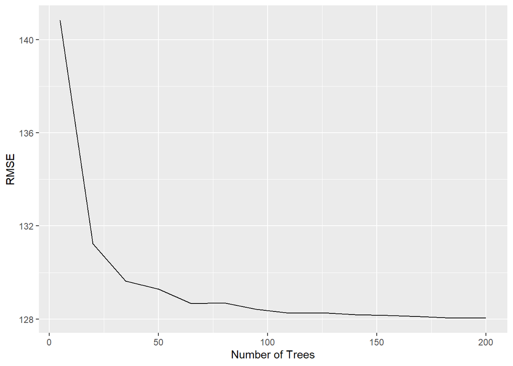

```r
rmses <- c()
for(i in 1:length(nbags)){

  rmses[i] = bags[[i]]$results$RMSE

}
ggplot()+
  geom_line(aes(x=nbags,y=rmses))+
  xlab('Number of Trees')+
  ylab('RMSE')
```

```r
nbags[which.min(rmses)]
```

```
## [1] 185
```

```r
predicted_te_mod1 <- predict(mod_1,games_test_turns_combo)

predicted_te_mod2 <- predict(mod_2,games_test_turns_combo)




predicted_te <- predict(bags[[14]],games_test_turns_combo)



# MAE
rf_mae <- mean(abs(games_test_turns_combo$rating - predicted_te))
# RMSE
rf_rmse <- sqrt(mean((games_test_turns_combo$rating - predicted_te)^2))
# R-square
rf_rsq <- cor(games_test_turns_combo$rating,predicted_te)^2

# MAE
mod1_mae <- mean(abs(games_test_turns_combo$rating - predicted_te_mod1))
# RMSE
mod1_rmse <- sqrt(mean((games_test_turns_combo$rating - predicted_te_mod1)^2))
# R-square
mod1_rsq <- cor(games_test_turns_combo$rating,predicted_te_mod1)^2

# MAE
mod2_mae <- mean(abs(games_test_turns_combo$rating - predicted_te_mod2))
# RMSE
mod2_rmse <- sqrt(mean((games_test_turns_combo$rating - predicted_te_mod2)^2))
# R-square
mod2_rsq <- cor(games_test_turns_combo$rating,predicted_te_mod2)^2



agg_perf <- c("Pure Game Data","Added Turn Data","Random Forest") %>%
    as_tibble() %>%
    mutate(rsq = c(mod1_rsq,mod2_rsq,rf_rsq),
           rmse = c(mod1_rmse,mod2_rmse,rf_rmse),
           mae = c(mod1_mae,mod2_mae,rf_mae))

kable(agg_perf,digits = 3)
```

| value | rsq | rmse | mae |
| --- | --- | --- | --- |
| Pure Game Data | 0.546 | 136.702 | 110.787 |
| Added Turn Data | 0.590 | 133.161 | 107.562 |
| Random Forest | 0.646 | 119.774 | 96.122 |

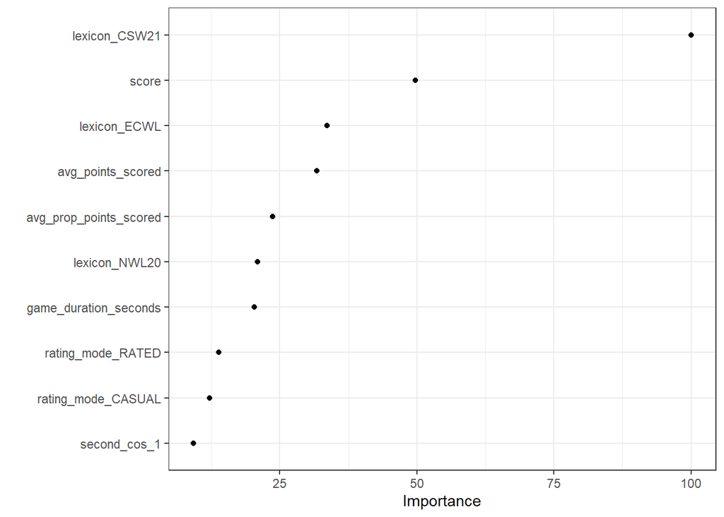

```r
vip(bags[[14]],num_features = 10, geom = "point") +
    theme_bw()
```

From an intial feature analysis, our random forest model is aso the most promising, as it values features that make intuitive sense - our average points scored, average proportion of points scored, player score, and how long the game took.